# Jeopardy Analysis

Elizabeth Wickes

October 27, 2014

# Data description

### Collection and preparation

A total of 7961 players were imported, representing the subset of players who were detected to be from the United States, with all duplicates removed. Duplicates were defined as entities with matching name and winnings values.

Data were pulled from player statistics HTML pages from [J-Archive!](http://j-archive.com/). Example page:  
http://j-archive.com/showplayerstats.php?player_id=8000.

All code to produce the associated CSV files is located in an IPython Notebook available for viewing and download [here](http://nbviewer.ipython.org/github/elliewix/JeopardyDOLData/blob/master/PreparePlayerFiles.ipynb). All original player and analysis files are available within [this github repository](http://nbviewer.ipython.org/github/elliewix/JeopardyDOLData/tree/master/).

The data have been split to only include players participating in 2003 and after, due to a rules change that removed the limit on the number of games in which each champion may compete. The frequencies of players participating in numbers of games are charted below.

### Exploring the impact of Ken Jennings

The majority of plots and other descriptives involving winnings utilize a dataset that excludes Ken Jennings. Ken is the highest winning player ever on Jeopardy!, with a total of $3,162,085.00. The standard deviation for the set of players after 2003 with Ken is $60,874.44 and is $38,146.19 when Ken is removed. His winnings have a z-score of 51.574 when compared to the data set including his value, and 82.3215 when excluding him. This z-score goes down to 29.8769 when looking just within the subset of players who have participated in more than one game.

| Data | Mean | SD |
| --- | --- | --- |
| 2003 and after, all players | $22,549.61 | $60,874.44 |
| 2003 and after, excluding Ken | $21,832.82 | $38,146.19 |

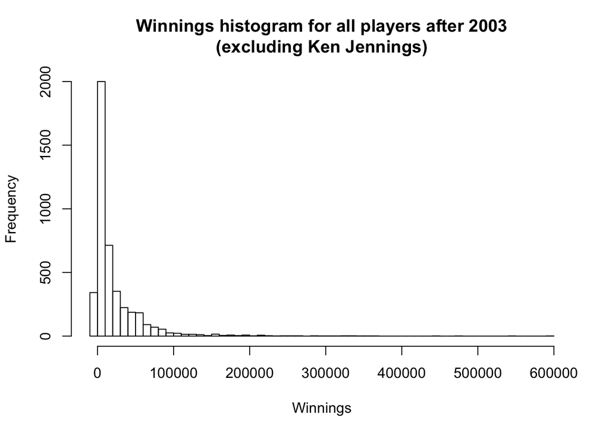

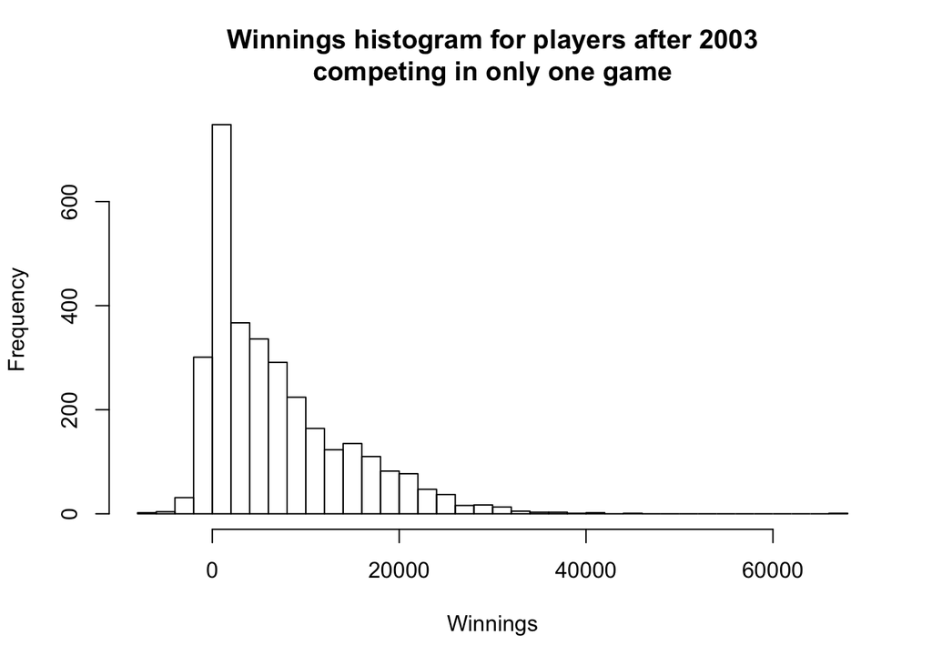

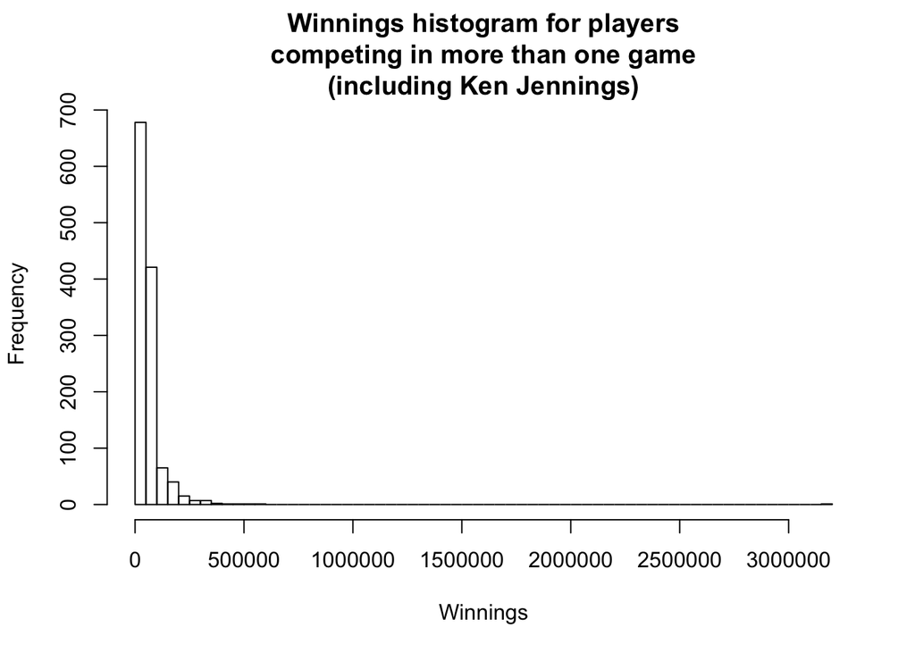

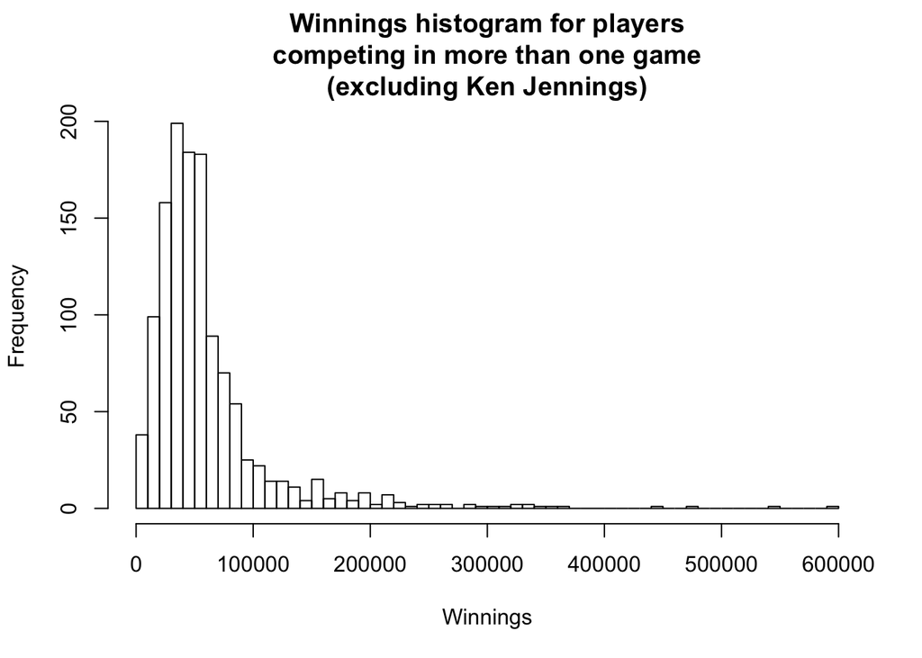

# Descriptive statistics

### Categorical values

| Variable | Value | Count | NAs |
| --- | --- | --- | --- |
| Occupation phrase | attorney | 287 | 51 |
| Location phrase | Los Angeles, California | 247 | 0 |
| Controlled state value | california | 1384 | 0 |
| SOC code | 56-MiscStudent | 1102 | 3212 |
| SOC major code | 56 | 1309 | 3212 |
| United States division | pacific | 1908 | 0 |
| United States region | region 3 | 2239 | 0 |

### Quantitative values

| Variable | Minimum | 1st Quartile | Median | Mean | 3rd Quartile | Maximum | NAs |
| --- | --- | --- | --- | --- | --- | --- | --- |
| Number of games participated in | 1 | 1 | 1 | 1.6156 | 2 | 85 | 0 |
| Total winnings | $-6,400.00 | $800.00 | $6,399.00 | $17,751.79 | $19,500.00 | $3,162,085.00 | 0 (False positives not being detected) |

### Summary of the 2003 subset

#### Winnings

| Data | n | Mean | Minimum | Maximum | SD |
| --- | --- | --- | --- | --- | --- |
| All players, 2003 and after | 4381 | $22,549.61 | $-6,400.00 | $3,162,085.00 | $60,874.44 |
| Players only participating in one game | 3141 | $6,900.13 | $-6,400.00 | $66,600.00 | $7,465.46 |
| Players participating in more than one game (including Ken Jennings) | 1240 | $62,190.73 | $0.00 | $3,162,085.00 | $103,755.72 |
| Players participating in more than one game (excluding Ken Jennings) | 1239 | $59,688.80 | $0.00 | $592,000.00 | $54,824.17 |

The $0 minimum values for the players participating in more than one game are likely artifacts of missing games in the database. Manual inspection of the data shows that there are only four of these cases.

#### Number of games participated in

| Variable | Minimum | 1st Quartile | Median | Mean | 3rd Quartile | Maximum | NAs |
| --- | --- | --- | --- | --- | --- | --- | --- |
| Numer of games participated in | 1 | 1 | 1 | 1.5896 | 2 | 85 | 0 |
| Total winnings | $-6,400.00 | $2,001.00 | $8,800.00 | $22,549.61 | $25,600.00 | $3,162,085.00 | 0 (False positives not being detected) |

#### Most common values for textual properties

| SOC_code | Freq |
| --- | --- |
| 56-MiscStudent | 657 |
| 23-1011 | 184 |
| 25-MiscTeacher | 164 |
| 25-2031 | 108 |
| 25-Prof | 101 |

| occ_phrase | Freq |
| --- | --- |
| attorney | 138 |
| senior | 99 |
| graduate student | 73 |
| junior | 64 |
| writer | 57 |

| state | Freq |
| --- | --- |
| california | 631 |
| new york | 421 |
| virginia | 233 |
| massachusetts | 214 |
| washington | 213 |

| SOC_major_code | Freq |
| --- | --- |
| 56 | 751 |
| 25 | 511 |
| 23 | 259 |
| 27 | 242 |
| 59 | 94 |

# Plots

Unless mentioned otherwise, all plots are using the data from after 2003.

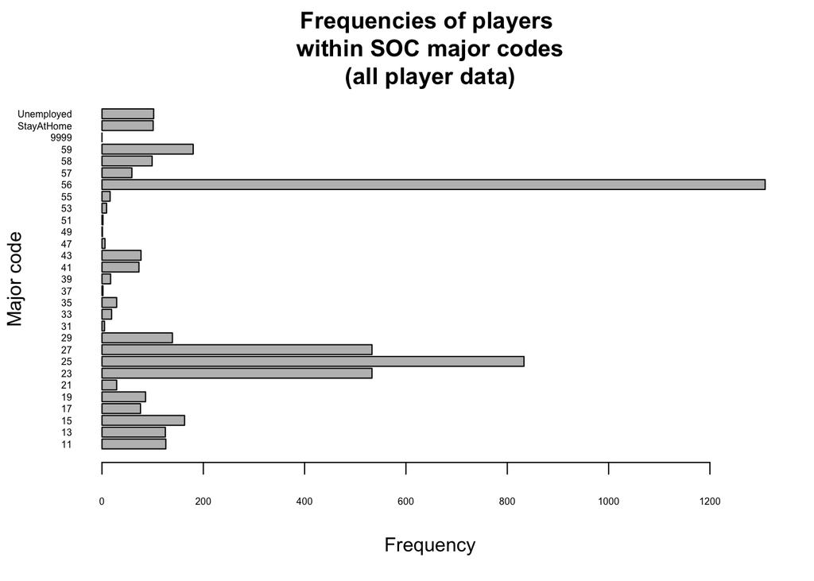

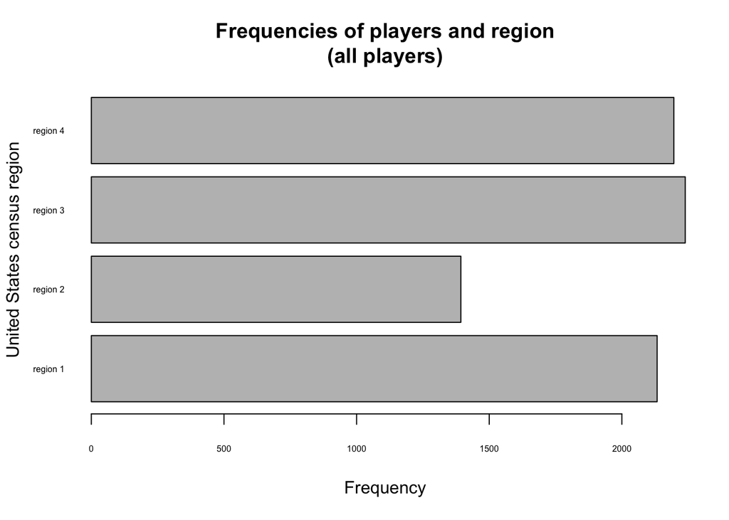

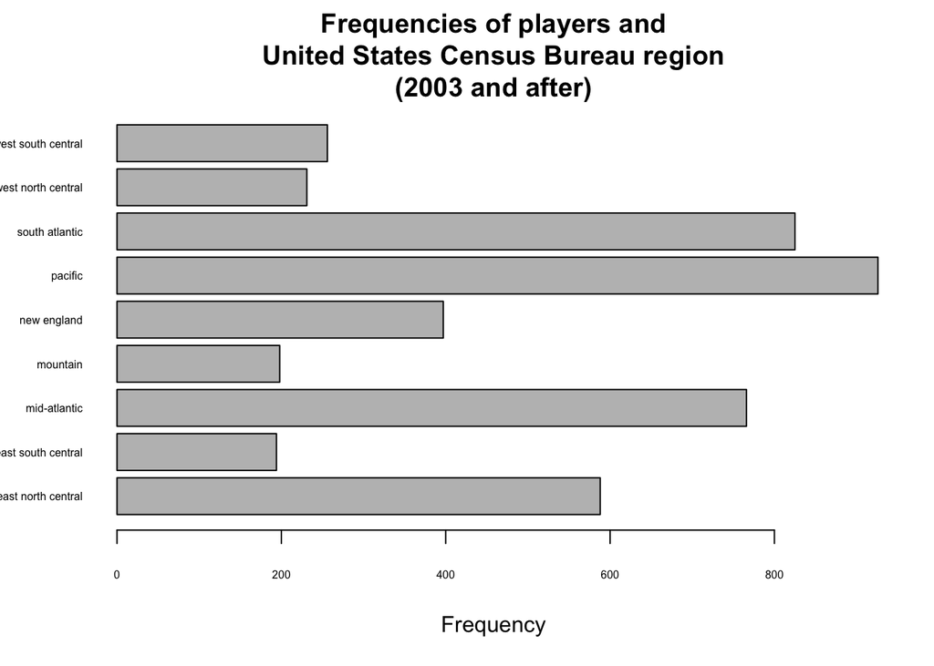

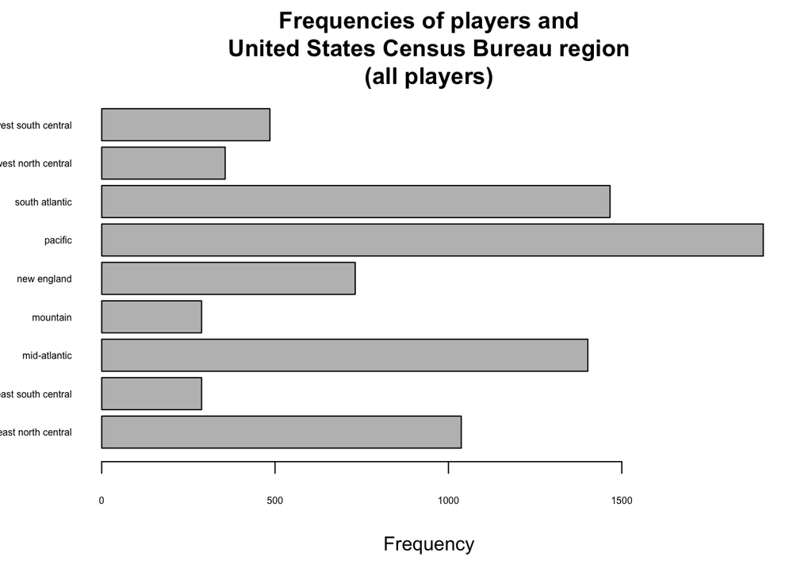

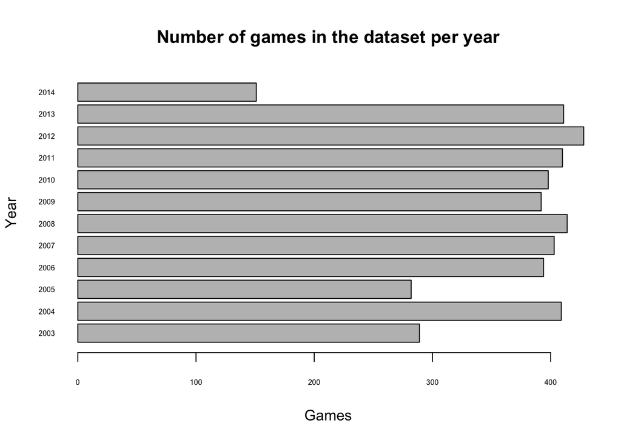

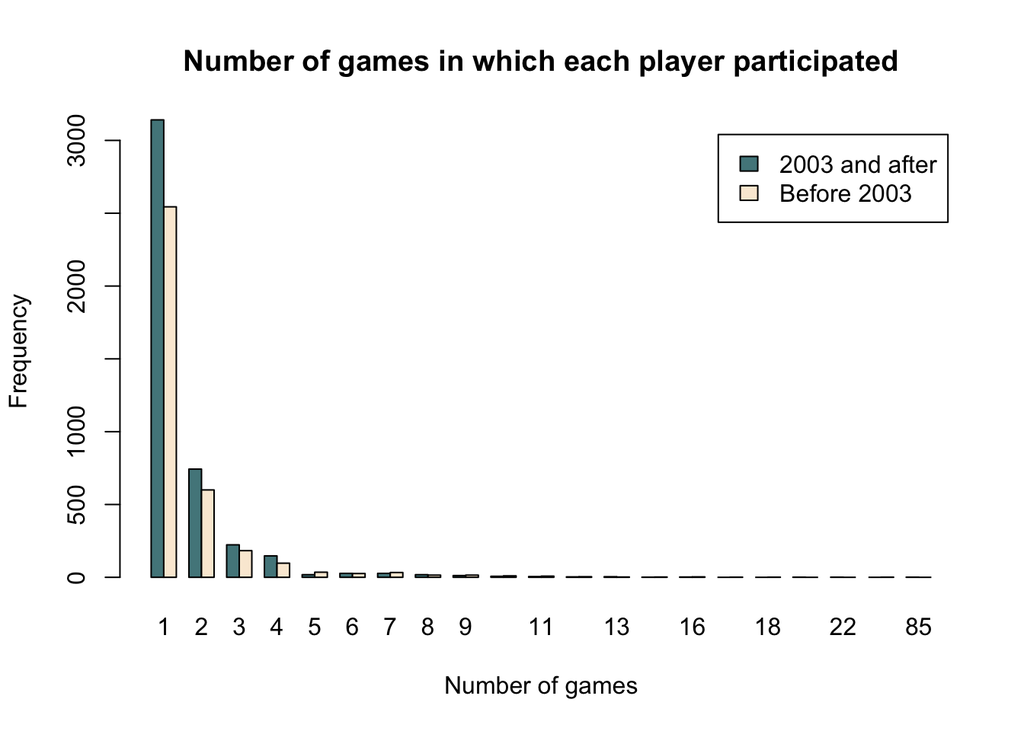

### Exploration of winnings and categorical data

The data below all exclude Ken Jennings.

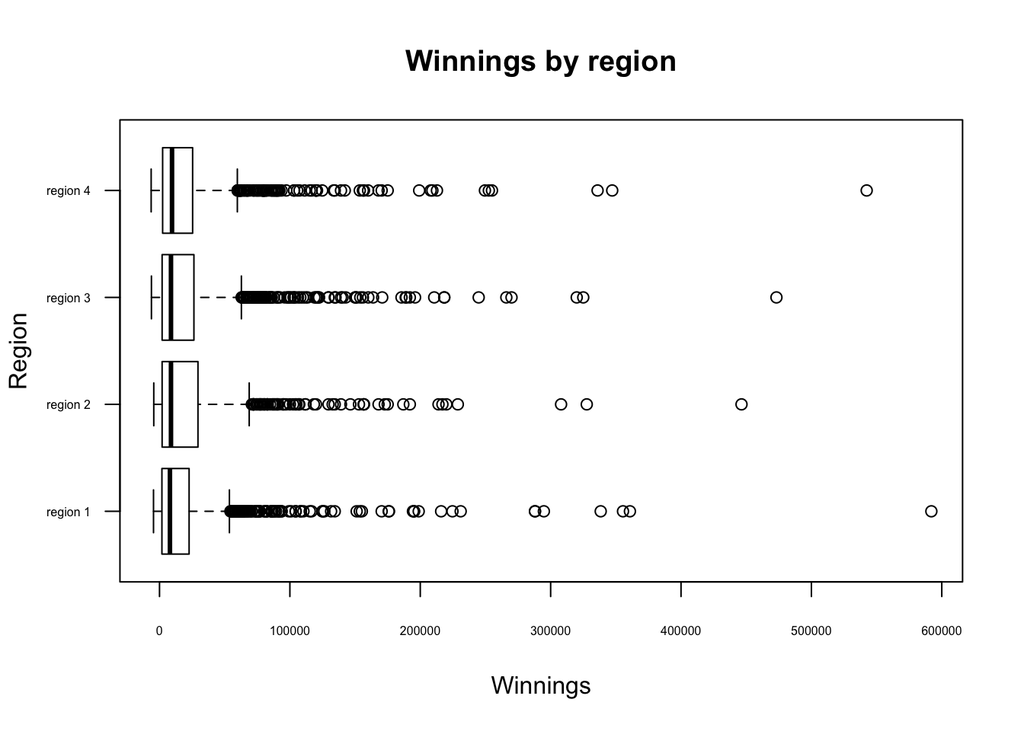

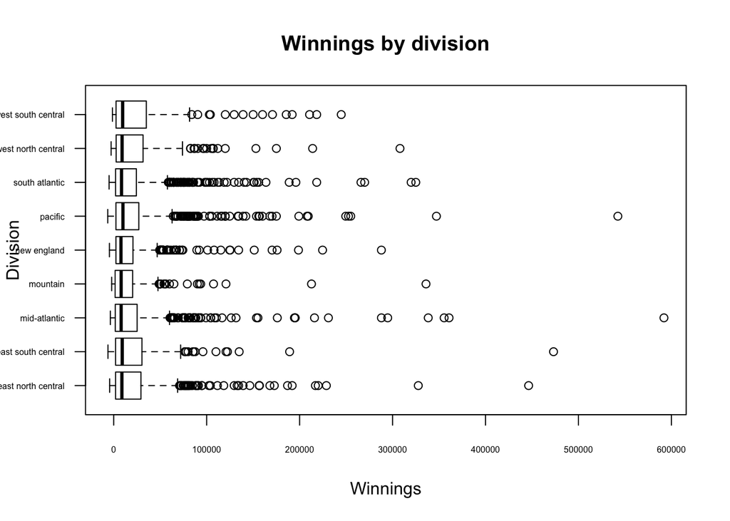

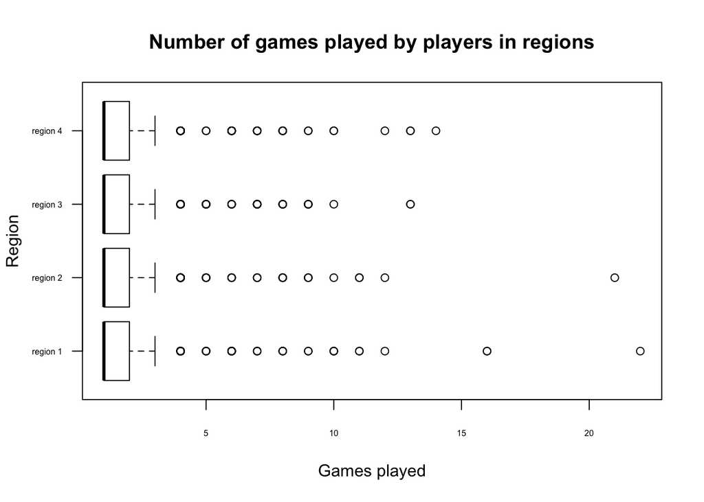

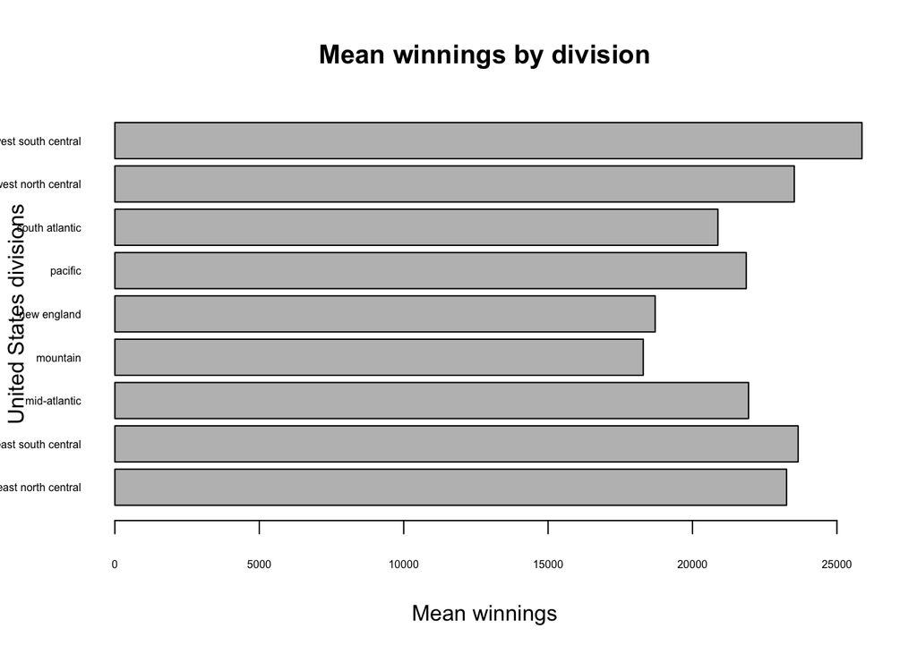

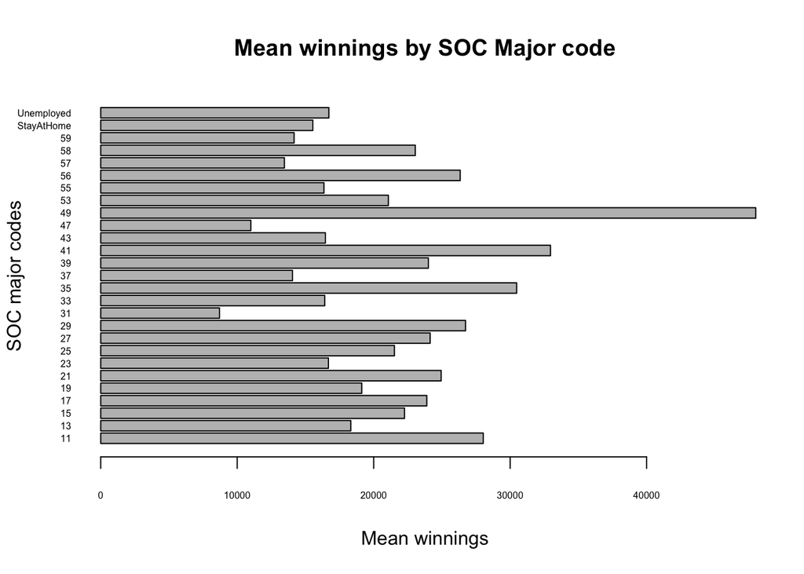

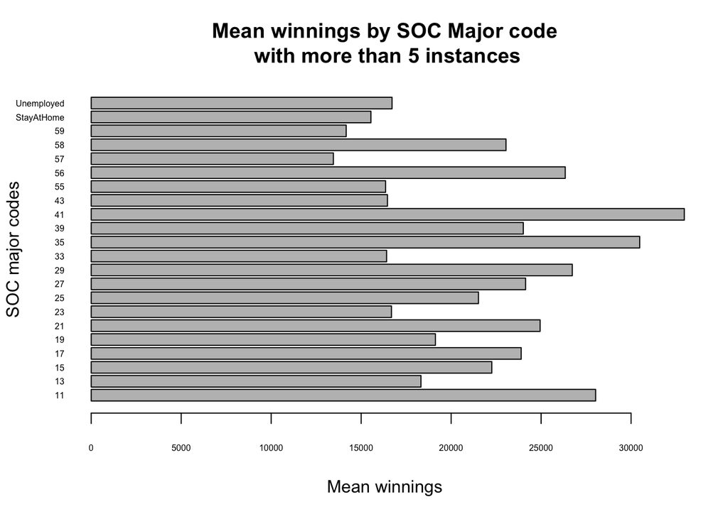

Several of the SOC major codes only have 1 to 5 players, so a subset of tabulations was created for better comparison between the groups.

### Plots showing the impact of Ken Jennings, using all data

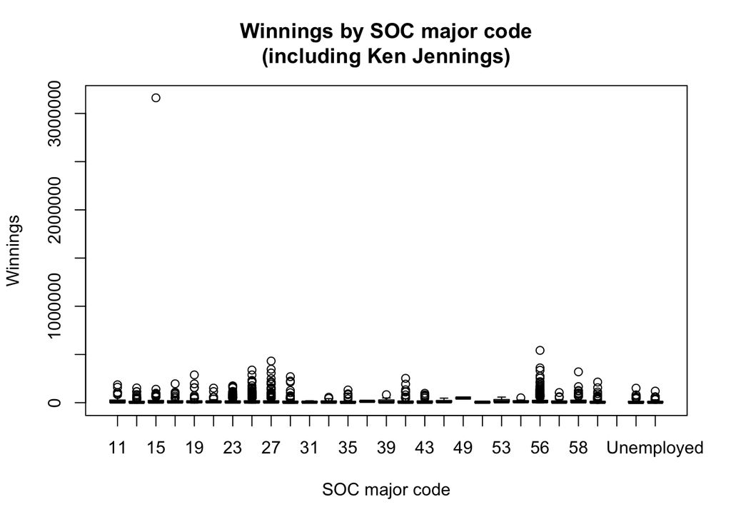

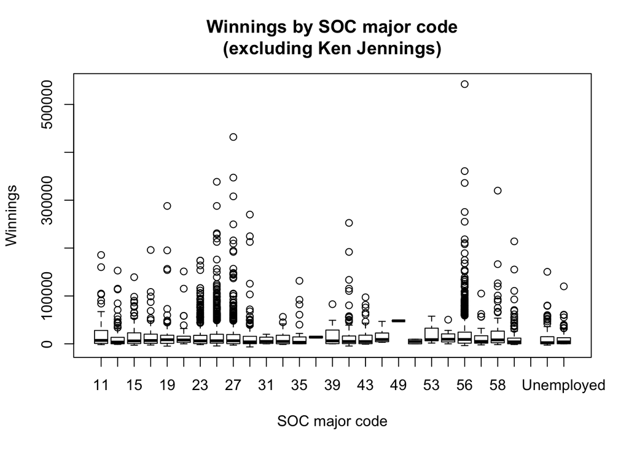

### Winnings over year of the show

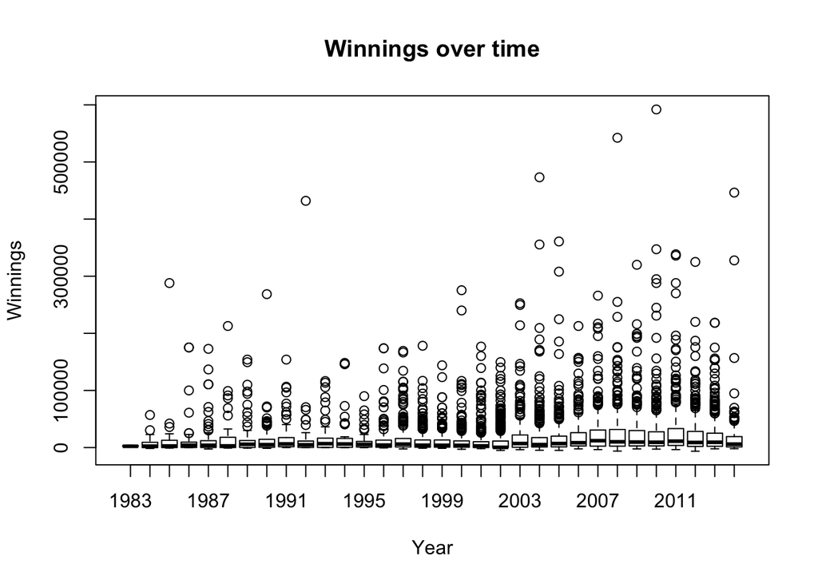

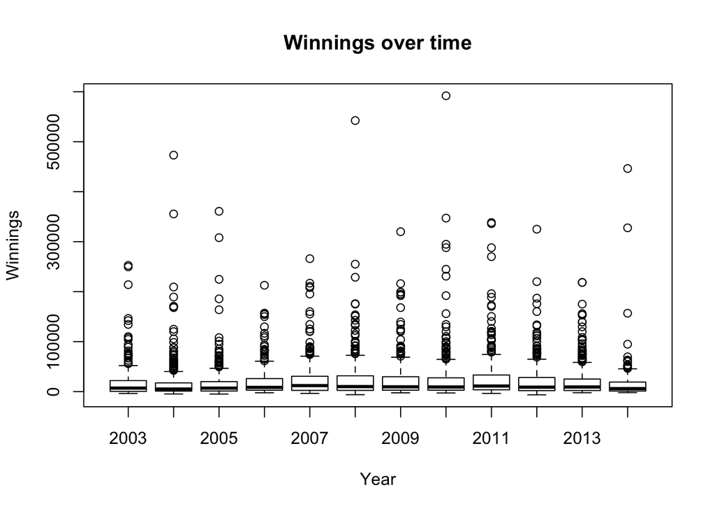

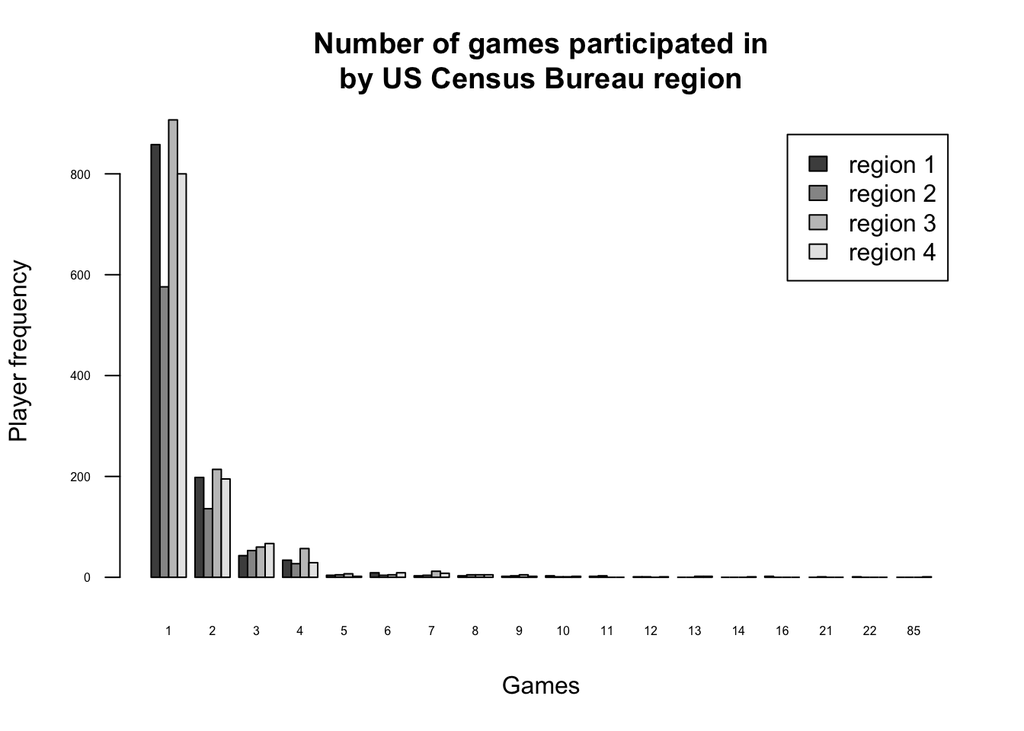

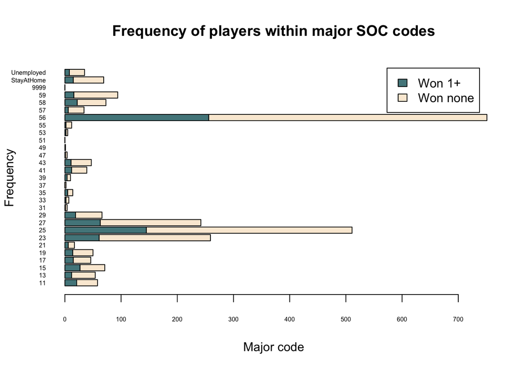

# Exploration of the BLS 2013 OES statistics

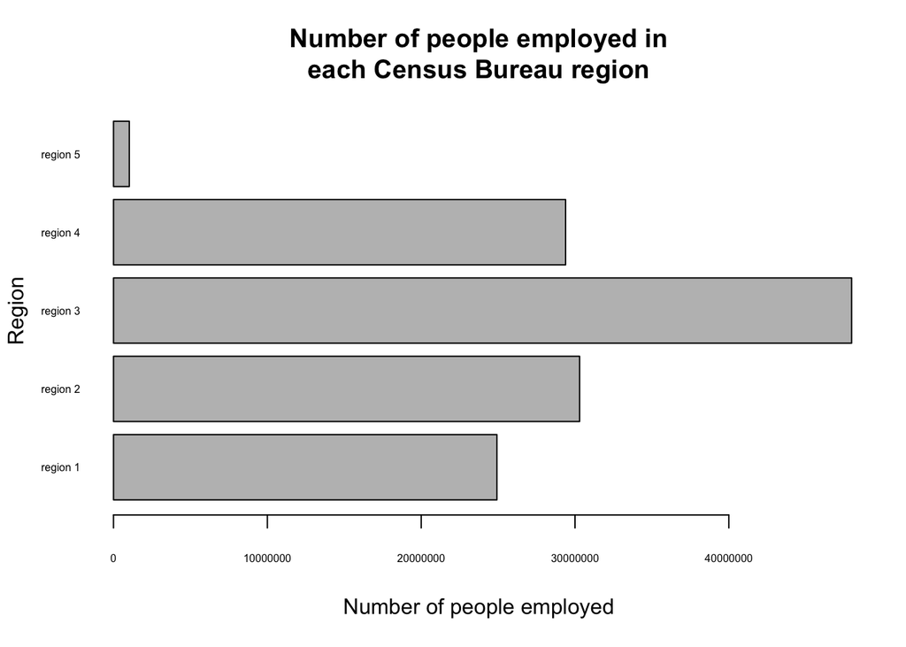

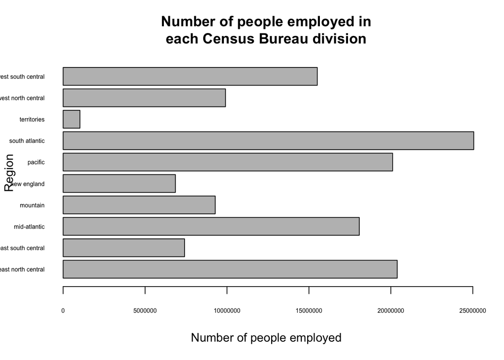

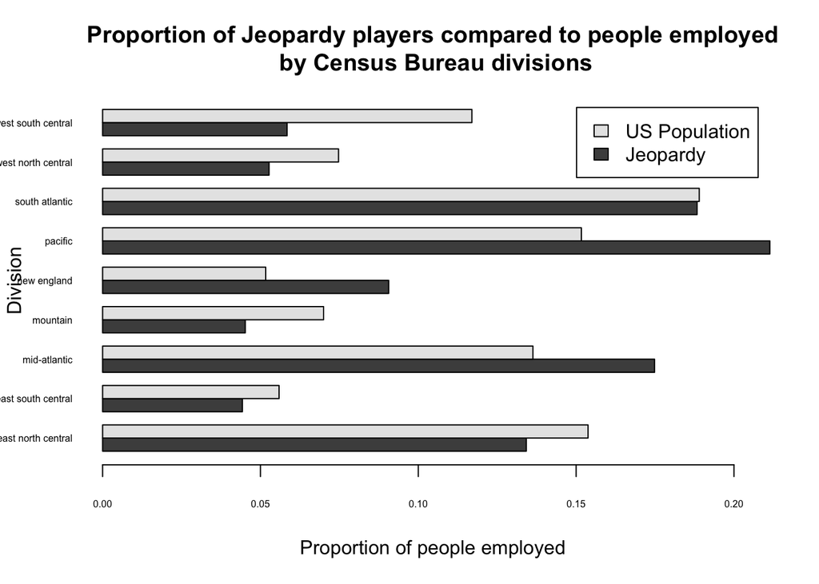